# Strategies and Panel Data

## Single Stock

Let's subset META (Facebook) and use that for the rest of the notebook.

```python
meta = df.groupby("Ticker").get_group("META").copy()
# 按ticker分类，摘取叫meta的group；copy创建副本以不影响原来的df
meta.set_index("DlyCalDt", inplace=True)
meta
```

| DlyCalDt | Ticker | DlyClose | DlyHigh | DlyLow | DlyOpen | DlyVolume | FastMA | SlowMA | Signal | Position | Returns | Strategy | BuyHold | MACS |
| --- | --- | --- | --- | --- | --- | --- | --- | --- | --- | --- | --- | --- | --- | --- |
| 2020-01-02 | META | 208.795944 | 208.805892 | 205.302415 | 205.780159 | 12077100 | NaN | NaN | 0 | NaN | NaN | NaN | NaN | NaN |
| 2020-01-03 | META | 207.691147 | 209.413027 | 205.979214 | 206.238004 | 11188400 | NaN | NaN | 0 | 0.0 | -0.005291 | -0.000000 | -0.005291 | 0.000000 |
| 2020-01-06 | META | 211.602722 | 211.781871 | 205.551241 | 205.730389 | 17058900 | NaN | NaN | 0 | 0.0 | 0.018834 | 0.000000 | 0.013443 | 0.000000 |
| 2020-01-07 | META | 212.060547 | 213.573421 | 210.756694 | 211.821682 | 14912400 | NaN | NaN | 0 | 0.0 | 0.002164 | 0.000000 | 0.015635 | 0.000000 |
| 2020-01-08 | META | 214.210419 | 215.225638 | 211.612661 | 212.000831 | 13475000 | 210.872156 | NaN | 0 | 0.0 | 0.010138 | 0.000000 | 0.025932 | 0.000000 |
| ... | ... | ... | ... | ... | ... | ... | ... | ... | ... | ... | ... | ... | ... | ... |
| 2024-12-23 | META | 599.316772 | 600.555721 | 585.728886 | 589.075884 | 10205800 | 598.927148 | 611.722028 | -1 | -1.0 | 0.024947 | -0.024947 | 1.870347 | -0.800099 |
| 2024-12-24 | META | 607.209778 | 607.449555 | 598.747336 | 602.184220 | 4726100 | 596.591223 | 610.615924 | -1 | -1.0 | 0.013170 | -0.013170 | 1.908149 | -0.802732 |
| 2024-12-26 | META | 602.813660 | 605.761050 | 598.407607 | 604.941771 | 6081400 | 597.822119 | 607.736475 | -1 | -1.0 | -0.007240 | 0.007240 | 1.887095 | -0.801303 |
| 2024-12-27 | META | 599.276855 | 601.315020 | 589.275743 | 598.877187 | 8084200 | 598.669373 | 604.692023 | -1 | -1.0 | -0.005867 | 0.005867 | 1.870156 | -0.800138 |
| 2024-12-30 | META | 590.714417 | 596.409362 | 585.059475 | 588.226640 | 7025900 | 599.866296 | 601.833557 | -1 | -1.0 | -0.014288 | 0.014288 | 1.829147 | -0.797282 |

1257 rows × 14 columns

### Exercise: BB Breakout

Implement an Bollinger Bands Breakout strategy and backtest it on META.

- First create high and low Bollinger Bands as usual (20-day MA; 2 std above + below)
- Then generate signals as follows:
  - Buy (+1) when the close price crosses above the upper band
    - Hold the position until a signal change
  - Sell (-1) when the close price crosses under the lower band
    - Hold the position until a signal change
- Generate positions
- Calculate the strategy returns and cumulative strategy returns
- Report and plot the cumulative strategy and market returns

**HINT** You can create an empty column by assigning it `np.nan`

```
           Ticker   BuyHold      MACS  Breakout
DlyCalDt
2024-12-30   META  1.829147 -0.797282  0.676445
```

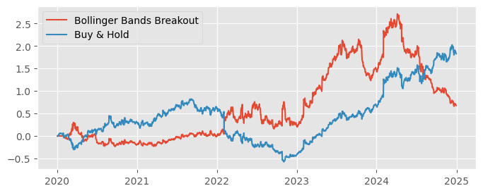

```python
# again,注意我们可以直接单独设置一个window的variable以方便未来的任何快速修改
WINDOW = 20
# 注意，这次的df不叫df，是meta，看上面的code，是meta =
meta["SMA"] = meta["DlyClose"].rolling(WINDOW).mean()
meta["DEV"] = meta["DlyClose"].rolling(WINDOW).std()
meta["HighBand"] = meta["SMA"] + 2 * meta["DEV"]
meta["LowBand"] = meta["SMA"] - 2 * meta["DEV"]

meta["Signal"] = np.nan
# np.nan是给meta新加一列叫"Signal"，一开始全部设为“空”（NaN = Not a Number）
meta.Signal = np.where(meta.DlyClose > meta.HighBand, 1, meta.Signal)
meta.Signal = np.where(meta.DlyClose < meta.LowBand, -1, meta.Signal)
meta.Signal = meta.Signal.ffill()
# 上面那个ffill就可以做到让那些没有超过两边的bond的情况都保持前一个signal的数据
# 发现还有missing value，是还没来得及生成signal导致的，那就fill with 0:
meta.Signal = meta.Signal.fillna(0)

meta["Position"] = meta.Signal.shift()
meta["Strategy"] = meta.Returns * meta.Position
meta["Breakout"] = (1 + meta.Strategy).cumprod() - 1

# 看看最终的数据展示每个strategy表现怎么样
print(meta.tail(1) [["Ticker", "BuyHold", "MACS", "Breakout"]])

plt.figure(figsize=(8,3))
plt.plot(meta.Breakout, label="Bollinger Bands Breakout")
plt.plot(meta.BuyHold, label="Buy & Hold")
plt.legend()
```

## Parameter Optimisation

Common **fast window sizes include 7, 20, 50** and common **slow window sizes include 50, 100, 200**.

However, beware of overfitting! When a model fits our historical data too closely, it can perform poorly in future real-world scenarios. 小心过拟合！当模型过于紧密地拟合历史数据时，它在未来实际情境中的表现可能会不佳。

### Exercise: Which windows?

The code below implements an Exponential Moving Average Crossover Strategy. Similar to our SMA strategy, but calculating the rolling mean in a different way that takes recent prices into greater consideration.

Unfortunately, the implementation with the window sizes below does not perform well. Modify the code below to perform a parameter optimisation on the strategy. Your code should be able to test 3 fast window sizes and 3 slow window sizes in combination.

Can you find a combination of window sizes that sees this EMA strategy outperform the simple Bollinger Band strategy above?

```python
# 从之前的coding来看，我们可以注意到的问题就是window到底用多少才合适？
# 以下EMA strategy(Exponential Moving Average Crossover Strategy)为例子，看window的重要性：
# EMA strategy：也是看fast穿过slow来定买卖策略；但越近的价格权重越大，反应更灵敏【EMA = 当前价格 × α + 前一天EMA × (1 - α)】

ema = meta.copy()

## MODIFY THIS CODE

fast_window, slow_window = 20, 100

ema["FastEMA"] = ema.DlyClose.ewm(span=fast_window, adjust=False).mean()
ema["SlowEMA"] = ema.DlyClose.ewm(span=slow_window, adjust=False).mean()

ema["Signal"] = np.where(ema.FastEMA > ema.SlowEMA, 1, -1)
ema["Signal"] = np.where(ema.SlowEMA.isna(), 0, ema.Signal)

ema["Position"] = ema.Signal.shift()
ema["StratRet"] = ema.Position * ema.Returns
ema["Strategy"] = (1 + ema.StratRet).cumprod() - 1

print("Short window:", fast_window, "Long window:", slow_window)
print("Cumulative Strategy Return is", ema.Strategy.iloc[-1])

# 上面simple market的结果是：1.829147；Bollinger Band strategy的结果是：0.676445
# EMA: 当Short window: 50 Long window: 200，Cumulative Strategy Return is 1.594839947209607
# EMA: 当Short window: 20 Long window: 100, Cumulative Strategy Return is 3.327660668030548 -- the best
# EMA: 当Short window: 7 Long window: 50, Cumulative Strategy Return is 1.9821538419987306
```

```
Short window: 20 Long window: 100
Cumulative Strategy Return is 3.327660668030548
```